Customer Revenue Analysis Farzam Juan Lin Thomas EIT Digital March 22, 2020

# 1.Introduction

The 80/20 rule has proven true for many businesses: only a small percentage of customers produce most of the revenue. As such, marketing teams are challenged to make appropriate investments in promotional strategies.

In this Google Merchandise Store (also known as GStore, where Google swag is sold) data set, we are required to analyze a customer dataset to predict revenue per customer. Hopefully, the outcome will be more actionable operational changes and a better use of marketing budgets for those companies who choose to use data analysis on top of GA data.

[figure not shown]

## 1.1. Data Fields

First, let’s look at what information our data captures. By using knitr and kableExtra , we can generate more beautiful html table.

Data Fields

| name | des |
| --- | --- |
| fullVisitorId | A unique identifier for each user of the Google Merchandise Store. |
| channelGrouping | The channel via which the user came to the Store. |
| date | The date on which the user visited the Store. |
| device | The specifications for the device used to access the Store. |
| geoNetwork | This section contains information about the geography of the user. |
| socialEngagementType | Engagement type, either ‘Socially Engaged’ or ‘Not Socially Engaged’. |
| totals | This section contains aggregate values across the session. |
| trafficSource | This section contains information about the Traffic Source from which the session originated. |
| visitId | An identifier for this session. This is part of the value usually stored as the _utmb cookie. This is only unique to the user. For a completely unique ID, you should use a combination of fullVisitorId… |
| visitNumber | The session number for this user. If this is the first session, then this is set to 1. |
| visitStartTime | The timestamp (expressed as POSIX time). |
| hits | This row and nested fields are populated for any and all types of hits. Provides a record of all page visits. |
| customDimensions | This section contains any user-level or session-level custom dimensions that are set for a session. This is a repeated field and has an entry for each dimension that is set. |

## 1.2.Goal

*What are we predicting?*

$$y_{user} = \sum_{i=1}^{n} transaction_{user_i}$$

$$target_{user} = \ln({y_{user}+1})$$

# 2.Preprocessing

## 2.1.Libraries

- [data.table](https://cran.r-project.org/web/packages/data.table/)
- [jsonlite](https://cran.r-project.org/web/packages/jsonlite/)
- [readr](https://cran.r-project.org/web/packages/readr/)
- [tidyr](https://cran.r-project.org/web/packages/tidyr/)
- [magrittr](https://cran.r-project.org/web/packages/magrittr/)
- [purrr](https://cran.r-project.org/web/packages/purrr/)
- [ggplot2](https://cran.r-project.org/web/packages/ggplot2/)
- [gridExtra](https://cran.r-project.org/web/packages/gridExtra/)
- [countrycode](https://cran.r-project.org/web/packages/countrycode/)
- [highcharter](https://cran.r-project.org/web/packages/highcharter/)
- [ggExtra](https://cran.r-project.org/web/packages/ggExtra/)
- [dplyr](https://cran.r-project.org/web/packages/dplyr/)
- [kableExtra](https://cran.r-project.org/web/packages/kableExtra/)
- [knitr](https://cran.r-project.org/web/packages/knitr/)
- [grid](https://cran.r-project.org/web/packages/grid/)
- [patchwork](https://cran.r-project.org/web/packages/patchwork/)

## 2.2.Load data and have a glimpse

```r
train_data <- read.csv('train.csv')

show(head(train_data, 1))
```

Data Fields

| channelGrouping | date | device | fullVisitorId | geoNetwork | sessionId | socialEngagementType | totals | trafficSource | visitId | visitNumber | visitStartTime |
| --- | --- | --- | --- | --- | --- | --- | --- | --- | --- | --- | --- |
| Organic Search | 20160902 | {“browser”: “Chrome”, “browserVersion”: “not available in demo dataset”, “browserSize”: “not available in demo dataset”, “operatingSystem”: “Windows”, “operatingSystemVersion”: “not available in demo … | 1.13166e+18 | {“continent”: “Asia”, “subContinent”: “Western Asia”, “country”: “Turkey”, “region”: “Izmir”, “metro”: “(not set)”, “city”: “Izmir”, “cityId”: “not available in demo dataset”, “networkDomain”: “ttnet.… | 1131660440785968503_1472830385 | Not Socially Engaged | {“visits”: “1”, “hits”: “1”, “pageviews”: “1”, “bounces”: “1”, “newVisits”: “1”} | {“campaign”: “(not set)”, “source”: “google”, “medium”: “organic”, “keyword”: “(not provided)”, “adwordsClickInfo”: {“criteriaParameters”: “not available in demo dataset”}} | 1472830385 | 1 | 1472830385 |

Here is one row of our data, and several of the columns(e.g. device, geographical and traffic information) in the data set contain json. They contain mutiple information in one feature, so we need a way to parse this into several columns.

```r
glimpse(train_data)
```

```
## Observations: 5,000
## Variables: 12
## $ channelGrouping      <fct> Organic Search, Organic Search, Organic Se…
## $ date                 <int> 20160902, 20160902, 20160902, 20160902, 20…
## $ device               <fct> "{\"browser\": \"Chrome\", \"browserVersio…
## $ fullVisitorId        <dbl> 1.131660e+18, 3.773060e+17, 3.895546e+18, …
## $ geoNetwork           <fct> "{\"continent\": \"Asia\", \"subContinent\…
## $ sessionId            <fct> 1131660440785968503_1472830385, 3773060208…
## $ socialEngagementType <fct> Not Socially Engaged, Not Socially Engaged…
## $ totals               <fct> "{\"visits\": \"1\", \"hits\": \"1\", \"pa…
## $ trafficSource        <fct> "{\"campaign\": \"(not set)\", \"source\":…
## $ visitId              <int> 1472830385, 1472880147, 1472865386, 147288…
## $ visitNumber          <int> 1, 1, 1, 1, 2, 1, 1, 1, 1, 1, 1, 1, 1, 1, …
## $ visitStartTime       <int> 1472830385, 1472880147, 1472865386, 147288…
```

Besides, some data type is not accurate(e.g. in date column, we get numeric type data), and we need to cast them to the correct form.

## 2.3.Cast data type

First, date information here is a numeric type, we need to convert them into type *date.time*, which is a build-in date type in R.

```r
# convert date column from character to Date class
train_data$date <- as.Date(as.character(train_data$date), format='%Y%m%d')

# convert visitStartTime to POSIXct
train_data$visitStartTime <- as_datetime(train_data$visitStartTime)
```

## 2.4.Deserialize json-like feature

By using `jsonlite` library, we can parse and split json format feature to what we want.[^1]

```r
tr_device <- paste("[", paste(train_data$device, collapse = ","), "]") %>% fromJSON(flatten = T)
tr_geoNetwork <- paste("[", paste(train_data$geoNetwork, collapse = ","), "]") %>% fromJSON(flatten = T)
tr_totals <- paste("[", paste(train_data$totals, collapse = ","), "]") %>% fromJSON(flatten = T)
tr_trafficSource <- paste("[", paste(train_data$trafficSource, collapse = ","), "]") %>% fromJSON(flatten = T)

train_data <- cbind(train_data, tr_device, tr_geoNetwork, tr_totals,
                    tr_trafficSource) %>% as.data.table()

# drop the old json columns
train_data[, c('device', 'geoNetwork', 'totals', 'trafficSource') := NULL]


show(head(train_data, 1))
```

Data Fields

| channelGrouping | date | fullVisitorId | sessionId | socialEngagementType | visitId | visitNumber | visitStartTime | browser | browserVersion | browserSize | operatingSystem | operatingSystemVersion | isMobile | mobileDeviceBranding | mobileDeviceModel | mobileInputSelector | mobileDeviceInfo | mobileDeviceMarketingName | flashVersion | language | screenColors | screenResolution | deviceCategory | continent | subContinent | country | region | metro | city | … |
| --- | --- | --- | --- | --- | --- | --- | --- | --- | --- | --- | --- | --- | --- | --- | --- | --- | --- | --- | --- | --- | --- | --- | --- | --- | --- | --- | --- | --- | --- | --- |
| Organic Search | 2016-09-02 | 1.13166e+18 | 1131660440785968503_1472830385 | Not Socially Engaged | 1472830385 | 1 | 2016-09-02 15:33:05 | Chrome | not available in demo dataset | not available in demo dataset | Windows | not available in demo dataset | FALSE | not available in demo dataset | not available in demo dataset | not available in demo dataset | not available in demo dataset | not available in demo dataset | not available in demo dataset | not available in demo dataset | not available in demo dataset | not available in demo dataset | desktop | Asia | Western Asia | Turkey | Izmir | (not set) | Izmir | … |

Now, it becomes readable for us and analyzable for R language.

## 2.3.Missing value process

First, we set all unknown value to build-in type *NA*. Some of the newly parsed columns from json have various values that can be converted to NA. This includes values such as ‘(not set)’ and ‘not available in demo dataset’. Although distinguishing between these values may be useful during modeling, we are going to convert them all to NA for the purposes of visualization.

```r
# values to convert to NA
na_vals <- c('unknown.unknown', '(not set)', 'not available in demo dataset',
             '(not provided)', '(none)', '<NA>')

for(col in names(train_data))
{
  set(train_data, i=which(train_data[[col]] %in% na_vals), j=col, value=NA)
}
```

Several of the columns newly parsed from json have only 1 unique value, e.g. ‘not available in demo dataset’. These columns are obviously useless, so we drop them here.

```r
# get number of unique values in each column
unique <- sapply(train_data, function(x) { length(unique(x[!is.na(x)])) })

# subset to == 1
one_val <- names(unique[unique <= 1])

# but keep bounces and newVisits
one_val = setdiff(one_val, c('bounces', 'newVisits'))

# drop columns from train_data
train_data[, (one_val) := NULL]
```

All of the columns that were converted from json are of class character. For some, we will need to change them to numeric by using *data.table* operation.[^2]

```r
# character columns to convert to numeric
num_cols <- c('hits', 'pageviews', 'bounces', 'newVisits',
              'transactionRevenue')

# change columns to numeric
train_data[, (num_cols) := lapply(.SD, as.numeric), .SDcols=num_cols]
```

For get better visualization, we convert *transactionRevenue* back to unit dollars.

```r
# Divide transactionRevenue by 1,000,000
train_data[, transactionRevenue := transactionRevenue / 1e+06]
```

## 2.4.Missing data visualization

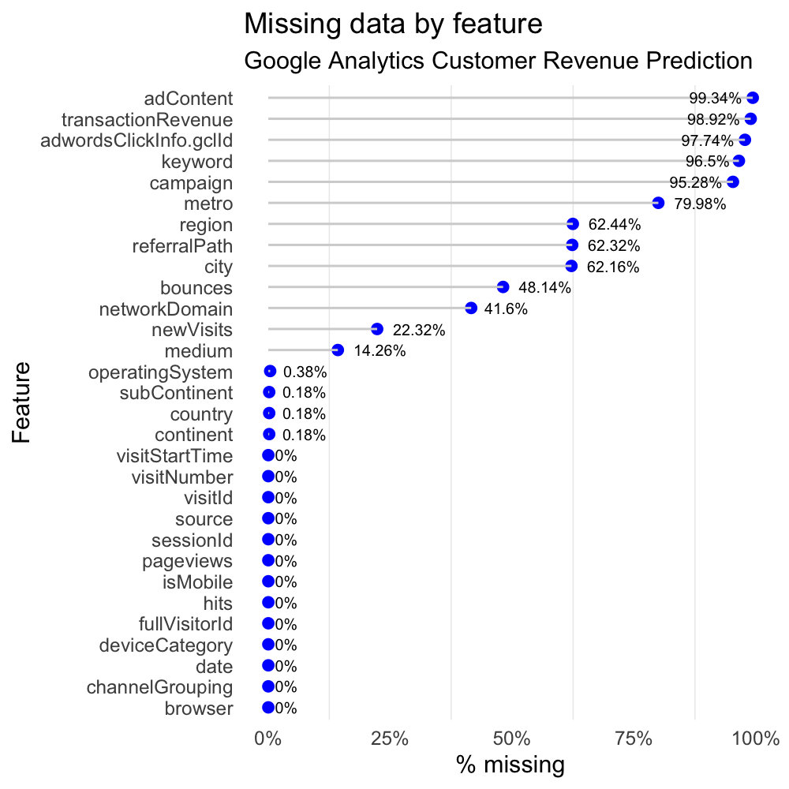

```r
# Cleveland plot
pm <- data.table(
  pmiss = sapply(train_data, function(x) { (sum(is.na(x)) / length(x)) }),
  column = names(train_data)
)


p <- pm %>%
  ggplot(aes(x=pmiss, y=reorder(column, pmiss))) +
  geom_point(color="blue", size = 2) +
  geom_segment(aes(x = 0, xend = pmiss,  y = reorder(column, -pmiss),  yend = reorder(column, -pmiss)), color = "lightgrey") +
  geom_text(data=pm[pm$pmiss< .8], aes(label = paste(round(100*pm[pm$pmiss<.8]$pmiss, 2), "%", sep="")), size = 2.5, hjust=-.3) +
  geom_text(data=pm[pm$pmiss>=.8], aes(label = paste(round(100*pm[pm$pmiss >=.8]$pmiss, 2), "%", sep="")), size = 2.5, hjust=1.2) +
  scale_x_continuous(labels = scales::percent) +
  labs (x = "% missing", y = "Feature",
        title = "Missing data by feature",
        subtitle = "Google Analytics Customer Revenue Prediction") +
  theme_minimal() +
  theme(panel.grid.major.x = element_blank(), panel.grid.major.y = element_blank())

p
```

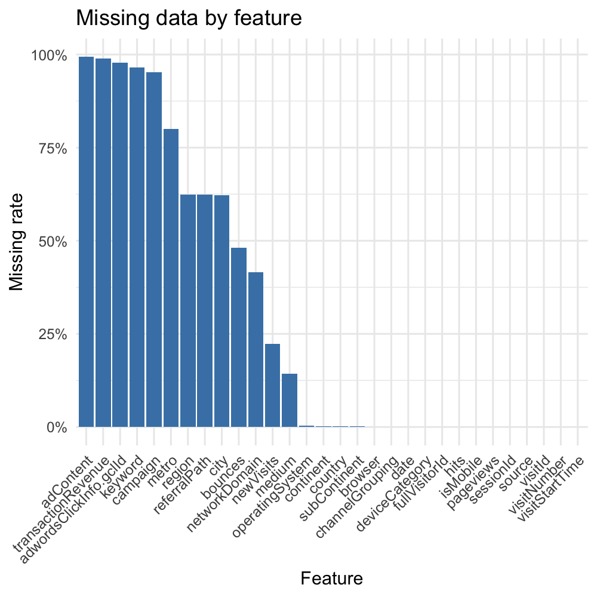

```r
p2 <- data.table(
  pmiss = sapply(train_data, function(x) { (sum(is.na(x)) / length(x)) }),
  column = names(train_data)
  ) %>%
ggplot(aes(x = reorder(column, -pmiss), y = pmiss)) +
geom_bar(stat = 'identity', fill = 'steelblue') +
  scale_y_continuous(labels = scales::percent) +
  labs(title='Missing data by feature',
    x='Feature',
    y='Missing rate') +
  theme_minimal() +
  theme(axis.text.x = element_text(angle = 45, hjust = 1))
p2
```

# Data Exploration

What is the time range over which these data were collected?

```r
time_range <- range(train_data$date)
print(time_range)
```

```
## [1] "2016-09-02" "2017-06-23"
```

*Target Variable (transaction revenue)*

The object of this competition is to predict total transaction revenue, so let’ take a look at this variable first. What is the range of transaction revenue, or dollars spent per visit.

```r
rev_range <- round(range(train_data$transactionRevenue, na.rm=TRUE), 2)
print(rev_range)
```

```
## [1]    5.15 1077.00
```

Now let’s look at the distribution of revenue from individual visits. Here I am using the log of transaction revenue to better display the distribution.

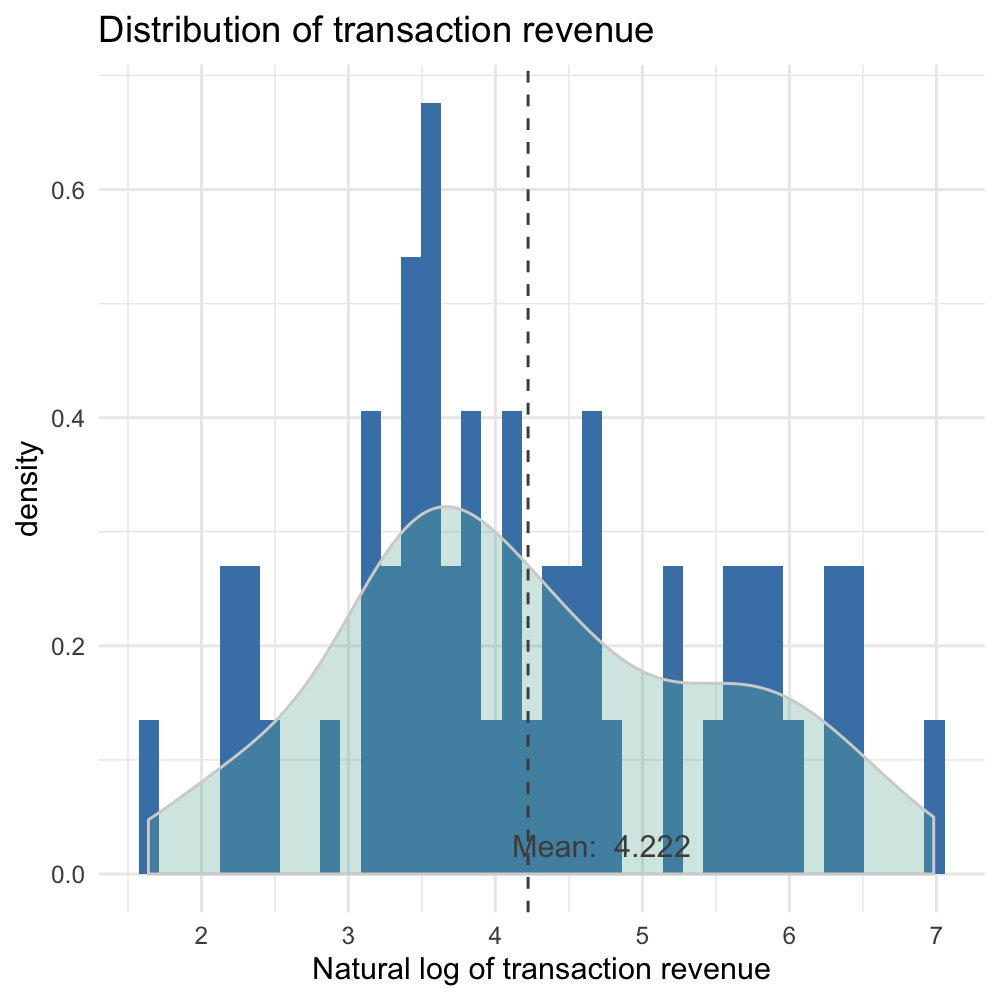

```r
meanRev <- mean(log(train_data$transactionRevenue), na.rm=TRUE)
train_data %>%
  ggplot(aes(x=log(transactionRevenue), y=..density..)) +
  geom_histogram(fill='steelblue', na.rm=TRUE, bins=40) +
  geom_density(aes(x=log(transactionRevenue)), fill='#69b3a2', color='lightgray', alpha=0.3, na.rm=TRUE) +
  geom_vline(xintercept = meanRev, size = .5, colour = "gray30", linetype = "dashed") +
  annotate(geom="text", x=meanRev+0.5, y=.025, label=paste("Mean: ",round(meanRev,3)), colour = "gray30") +
  labs( title = 'Distribution of transaction revenue',
    x = 'Natural log of transaction revenue'
  ) + theme_minimal()
```

The mean of the natural log of transaction revenue appears to be around 4 and is approximately normally distributed.

Now let’s look at transaction revenue grouped by channel, which is the way in which the user came to the Google Merchandise Store.

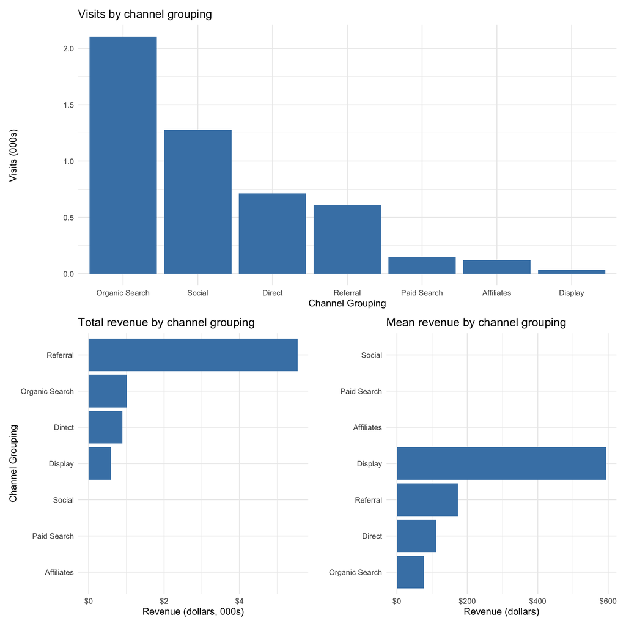

```r
g1 <- train_data[, .(n = .N), by=channelGrouping] %>%
  ggplot(aes(x=reorder(channelGrouping, -n), y=n/1000)) +
  geom_bar(stat='identity', fill='steelblue') +
  labs(x='Channel Grouping',
       y='Visits (000s)',
       title='Visits by channel grouping') + theme_minimal()

g2 <- train_data[, .(revenue = sum(transactionRevenue, na.rm=TRUE)), by=channelGrouping] %>%
  ggplot(aes(x=reorder(channelGrouping, revenue), y=revenue/1000)) +
  geom_bar(stat='identity', fill='steelblue') +
  scale_y_continuous(label = scales::dollar) +
  coord_flip() +
  labs(x='Channel Grouping',
       y='Revenue (dollars, 000s)',
       title='Total revenue by channel grouping') + theme_minimal()

g3 <- train_data[, .(meanRevenue = mean(transactionRevenue, na.rm=TRUE)), by=channelGrouping] %>%
  ggplot(aes(x=reorder(channelGrouping, meanRevenue), y=meanRevenue)) +
  geom_bar(stat='identity', fill='steelblue') +
  scale_y_continuous(label = scales::dollar) +
  coord_flip() +
  labs(x='',y='Revenue (dollars)',
       title='Mean revenue by channel grouping') + theme_minimal()


g1 / (g2+g3)
```

We see that in terms of total revenue, “Referral” accounts for the largest share. “Display” had the highest average revenue, but be aware that this may be due to a particularly large transaction, as the number of visits from “Display” are very small.

## Device Features

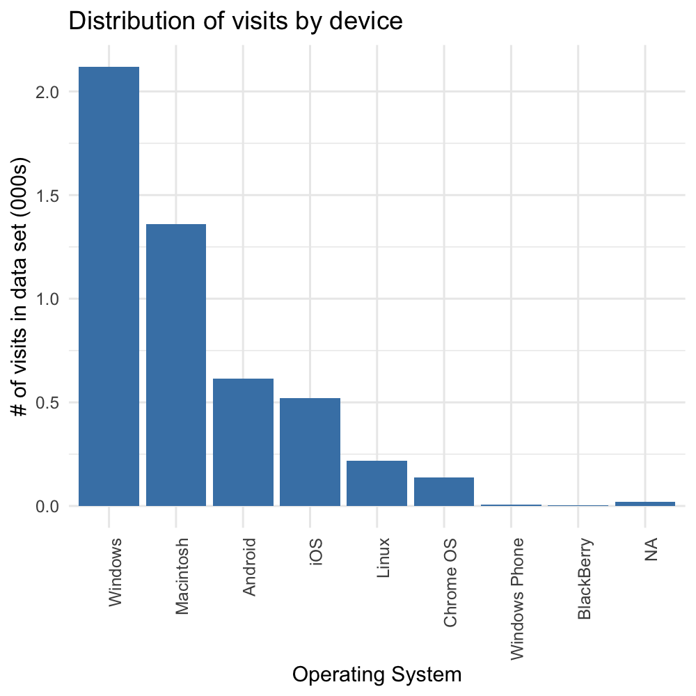

```r
g1 <- train_data[, .(n=.N/1000), by=operatingSystem][
  n > 0.001
] %>%
  ggplot(aes(x=reorder(operatingSystem, -n), y=n)) +
  geom_bar(stat='identity', fill='steelblue') +
  labs(x='Operating System',
       y='# of visits in data set (000s)',
       title='Distribution of visits by device') +
  theme_minimal() +
  theme(axis.text.x = element_text(angle = 90, hjust = 1))


g1
```

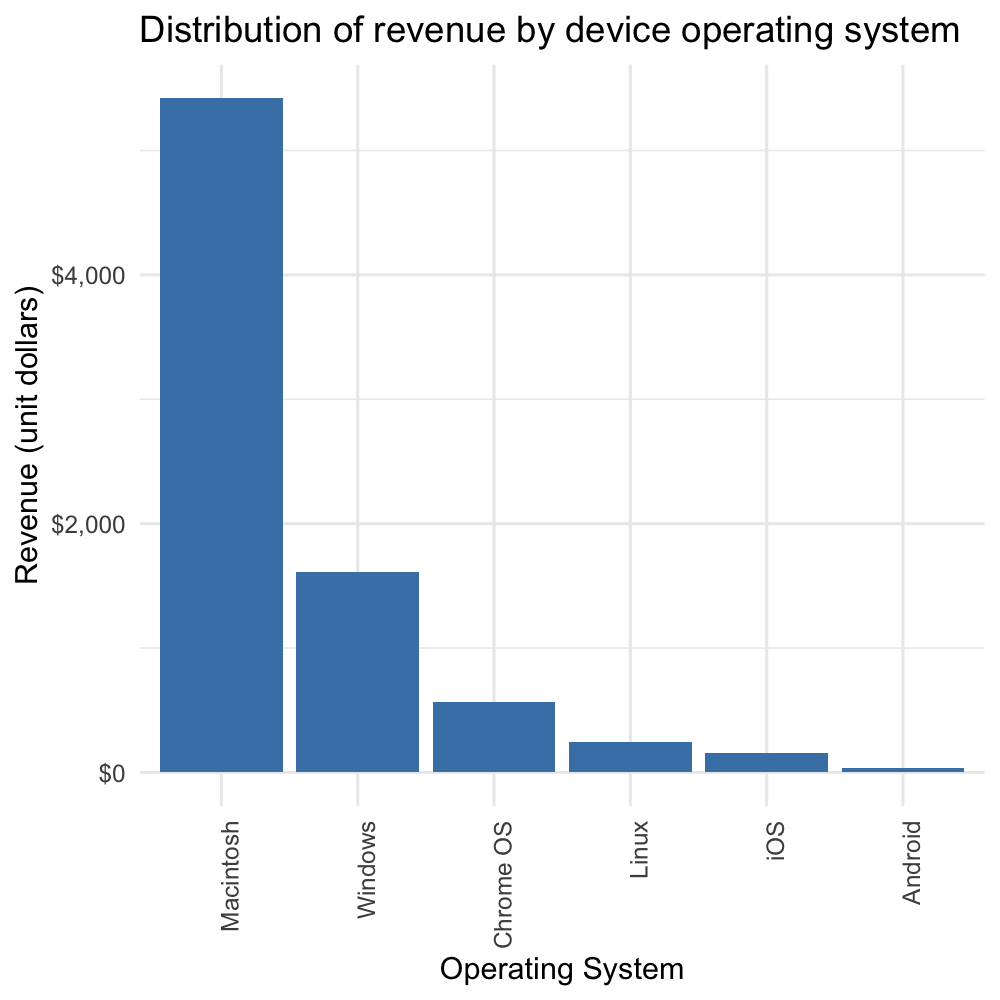

```r
g2 <- train_data[, .(revenue = sum(transactionRevenue, na.rm=TRUE)), by=operatingSystem][
  revenue > 0,
] %>%
  ggplot(aes(x=reorder(operatingSystem, -revenue), y=revenue)) +
  geom_bar(stat='identity', fill='steelblue') +
  scale_y_continuous(label = scales::dollar) +
  labs(x='Operating System',
       y='Revenue (unit dollars)',
       title='Distribution of revenue by device operating system') +
  theme_minimal() +
  theme(axis.text.x = element_text(angle = 90, hjust = 1))

g2
```

Interestingly, we see that although Windows accounted for more records in the data set than any other operating system, Macintosh accounted for more of transaction revenue than other operating systems by a large margin.

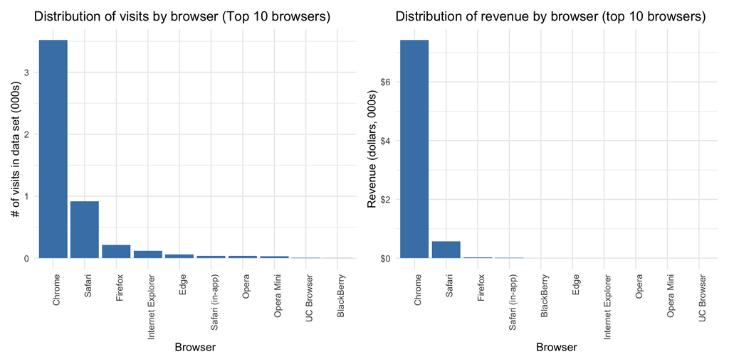

```r
g1 <- train_data[, .(n=.N/1000), by=browser][
  1:10
] %>%
  ggplot(aes(x=reorder(browser, -n), y=n)) +
  geom_bar(stat='identity', fill='steelblue') +
  labs(x='Browser',
       y='# of visits in data set (000s)',
       title='Distribution of visits by browser (Top 10 browsers)') +
  theme_minimal() +
  theme(axis.text.x = element_text(angle = 90, hjust = 1))

g2 <- train_data[, .(revenue = sum(transactionRevenue, na.rm=TRUE)/1000), by=browser][
  1:10
] %>%
  ggplot(aes(x=reorder(browser, -revenue), y=revenue)) +
  geom_bar(stat='identity', fill='steelblue') +
  scale_y_continuous(label = scales::dollar) +
  labs(x='Browser',
       y='Revenue (dollars, 000s)',
       title='Distribution of revenue by browser (top 10 browsers)') +
  theme_minimal() +
  theme(axis.text.x = element_text(angle = 90, hjust = 1))

g1+g2
```

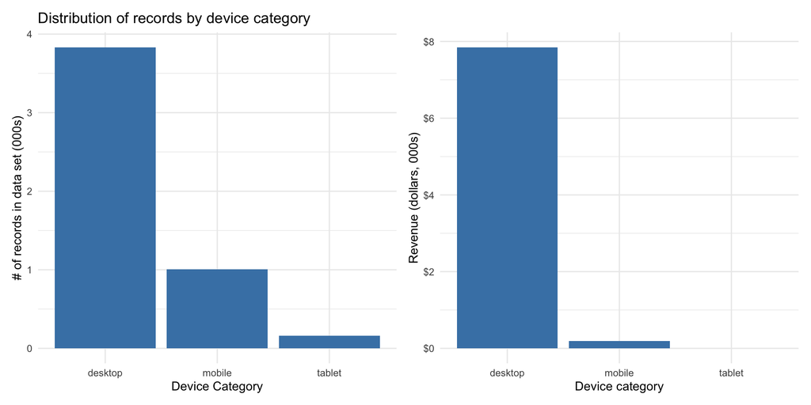

```r
g1 <- train_data[, .(n=.N/1000), by=deviceCategory]%>%
  ggplot(aes(x=reorder(deviceCategory, -n), y=n)) +
  geom_bar(stat='identity', fill='steelblue') +
  labs(x='Device Category',
       y='# of records in data set (000s)',
       title='Distribution of records by device category') +
  theme_minimal()

g2 <- train_data[, .(revenue = sum(transactionRevenue, na.rm=TRUE)/1000), by=deviceCategory] %>%
  ggplot(aes(x=reorder(deviceCategory, -revenue), y=revenue)) +
  geom_bar(stat='identity', fill='steelblue') +
  scale_y_continuous(label = scales::dollar) +
  labs(x='Device category',
       y='Revenue (dollars, 000s)') +
  theme_minimal()

g1 + g2
```